# Lesson155 · Manual features vs RDL: compare quality and human effort

Teacher solution · TierB full real F1 data. PROVIDED / TODO / CHECK / EXIT. Default CPU execution replays real author predictions offline. Three live functions construct the report and validate your effort log. Full FE and GNN gates require separate pinned runtimes and are off by default.

```python
# @colab-bootstrap: offline default audit; numpy and IPython required.
import os,sys,io,copy,gzip,base64,hashlib,json,math,statistics,tempfile,zlib
from datetime import datetime
from pathlib import Path
import numpy as np
from IPython.display import display,Markdown
os.environ.update(OMP_NUM_THREADS='1',MKL_NUM_THREADS='1',OPENBLAS_NUM_THREADS='1')
RUN_FULL_FE_REPRODUCTION=False
RUN_FULL_GNN_REPRODUCTION=False
```

## 1 · A good score does not tell you how much work it took

**Reading route.** Match the queries → compare complete pipelines → inspect paired errors → separate human and machine time → bound the claim.

**Your win:** produce a comparison that answers two separate questions: how accurate were the predictions, and how much human work was observed? Read the core lesson in about 25 minutes; use a separate session for the notebook and prospective effort log.

[Lesson 154](https://avistian.github.io/relational/lessons/0154-portfolio-synthesis.html) assembled the portfolio without filling missing comparisons. It left us with two completed test tasks, an incomplete recommendation run, and no fresh matched manual-feature baseline in that report. Today we add one fresh matched case: **rel-f1/driver-position**. The other gaps remain visible.

Our mission is to test whether relational learning unlocks useful predictive signal without repeated manual feature design. That claim has two parts. A model-score replay can test predictive quality. It cannot recover the hours someone spent understanding a schema or inventing features.

**Prerequisites, recalled here:** a query is an entity and a prediction cutoff; the cutoff says when its information must be available. Validation selects a model before test scoring. **MAE**, mean absolute error, averages `abs(target − prediction)` over queries; lower is better. A **seed** sets pseudorandom choices for a training run. Repeated seeds measure one kind of variability on the same data.

## 2 · Put both complete pipelines on the same query table

For this task, each target is a driver's average finishing position over the next 60 days. Both arms use all 7,453 training, 499 validation and 760 test queries. Those labels are independently reconstructed from raw race results before fitting. **Matched** means the same task, target definition, query population, split and scoring rule.

A **hyperparameter** is a setting chosen outside the weight-fitting loop, such as tree depth or learning rate. A **checkpoint** is saved neural-network weights. A **fanout** caps sampled neighbors at a graph hop; the **root** is the driver whose prediction we read.

The FE arm uses the researcher's released SQL: 50 engineered fields plus numeric driver ID. SQL is the language used to join tables and compute features. One field retrieves historical driver standing; another looks at a scheduled upcoming circuit. A train-fitted encoder turns the resulting row into the matrix accepted by LightGBM, a sum of decision trees. Each search tries 10 hyperparameter settings and selects the lowest validation MAE; it then refits that setting on training rows.

The RDL arm converts table rows into graph nodes and foreign-key relationships into edges. Typed row encoders produce 128-dimensional vectors. Two GraphSAGE layers aggregate sampled neighbors, while time features express how old each row is relative to its owner's query cutoff. A scalar head predicts the finishing-position target. Ten full epochs are run; the earliest strictly best validation checkpoint is restored for scoring. The released evaluator clips predictions to the training-target 2nd/98th percentiles.

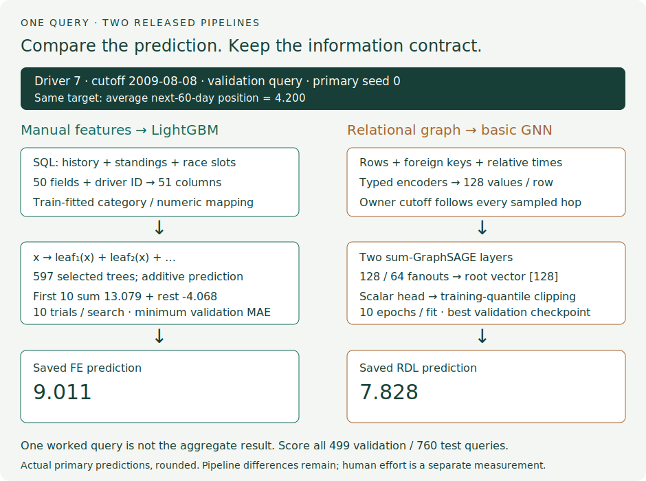

Actual validation query for driver 7 at cutoff 2009-08-08: trace FE tree sums and the basic GNN prediction. The complete held-out populations, not this example, determine the comparison.

**Trace the pictured query.** For driver 7 at the 2009-08-08 cutoff, the target is 4.200. The first ten FE trees sum to 13.079; the remaining trees add −4.068, giving 9.011 after rounding. The basic GNN predicts 7.828. RDL is closer on this one validation query. Section 3 scores the complete query populations; one favorable example cannot establish an overall advantage.

**Held fixed:** full query populations, temporal split, labels and MAE. **Varied:** the entire released pipeline—features, preprocessing, model and search procedure. Five full runs per arm retain every trial and selection trace. The [visible implementations](https://avistian.github.io/relational/labs/0155-compare-manual-fe.ipynb) include SQL, graph construction, model, training loop and search; the pinned library kernels are dependencies.

> **Scope check.** This is not an isolated architecture experiment. FE uses train-fitted preprocessing; the released GNN computes database statistics through the test cutoff. FE has strict-past history joins; the sampler permits times equal to the query cutoff. Schedule-publication and mutable-attribute histories are unavailable. The [protocol ledger](https://avistian.github.io/relational/labs/l155-reproduction.md) preserves these limits.

The [paper's Table 7](https://arxiv.org/html/2407.20060v1#A2.T7) provides the basic-GNN target. Its manual-FE study is a different comparison: **Figure 3 regression uses a boosted GNN**. We execute the released FE recipe against the basic GNN and do not relabel that as reproducing Figure 3.

## 3 · Compare errors only after matching identities

**Worked example, synthetic.** Ada has two queries, at cutoffs 10 and 20, with targets 4 and 8. FE predicts 3 and 6; RDL predicts 6 and 8. Their errors are `[1, 2]` and `[2, 0]`. FE MAE is 1.5; RDL MAE is 1.0. The benefit `FE MAE − RDL MAE` is +0.5 finishing positions, favoring RDL. RDL still loses on the first query.

The same entity appears twice, so joining on driver ID alone is ambiguous. Use `(driver_id, cutoff)` and reject duplicate or missing keys. Reversing prediction row order must leave the result unchanged.

**Lab task 1 — `paired_losses`.** Align both prediction sets to the full target key set. Reject invalid evidence, compute each query's two absolute errors, and return their signed difference. The actual report will call your function on every saved prediction pair.

Predict before reading: does closeness to a paper score establish a win over FE?

| Split | FE MAE mean ± seed SD | Basic RDL MAE mean ± seed SD | FE − RDL MAE |
| --- | --- | --- | --- |
| val | 2.777330 ± 0.027905 | 3.168988 ± 0.030376 | -0.391658 |
| test | 3.948917 ± 0.070469 | 4.013141 ± 0.208250 | -0.064225 |

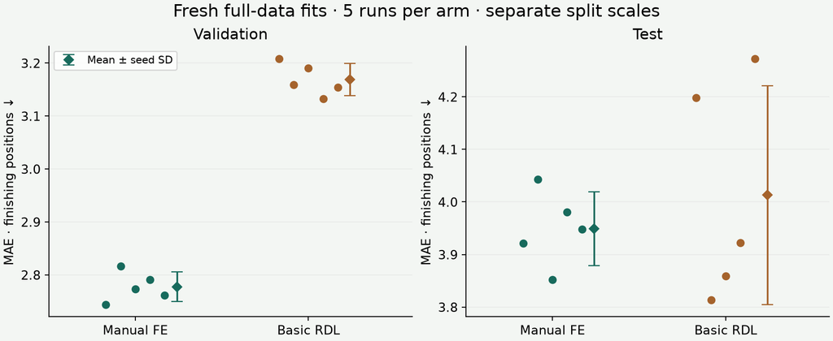

Actual fresh primary fits: points are runs; diamonds and bars show mean and sample seed SD. Separate vertical scales preserve within-split readability.

**Measured result:** FE's test MAE is **3.9489**, compared with **4.0131** for basic RDL. The signed RDL benefit is **-0.0642 finishing positions**. The driver-cluster conditional 95% interval is **[-0.3123, +0.1730]**. It crosses zero; the point estimate favors FE, but this does not establish superiority or equivalence. The GNN mean is within the frozen ±0.20 descriptive band around Table 7's 4.022.

The plot shows each run and its arm's mean±sample seed standard deviation. Standard deviation describes variation among these five runs; it is not uncertainty across databases. Matching seed numbers do not make FE search randomness and neural initialization a paired random experiment. The comparison pairs **query losses** instead.

A second uncertainty view resamples entire drivers, keeping each driver's cutoff queries together. It uses the per-query error averaged across the five fits. This **cluster bootstrap** gives a conditional 95% interval for this evaluation population. It does not account for every shared race/time effect or training uncertainty. Prior lessons already exposed this test split, so treat the result as a reproduction comparison, not untouched confirmatory evidence.

```python
# TODO: live report/effort contract.
def paired_losses(queries, fe_predictions, rdl_predictions):
    """Align by the complete query key. Positive benefit favors RDL."""
    def keyed(rows,value):
        result={}
        for row in rows:
            key=(row['entity'],row['time']);v=float(row[value])
            if key in result or not math.isfinite(v):raise ValueError('Duplicate query or nonfinite value')
            result[key]=v
        return result
    truth=keyed(queries,'target');fe=keyed(fe_predictions,'prediction');rdl=keyed(rdl_predictions,'prediction')
    if not truth or set(truth)!=set(fe) or set(truth)!=set(rdl):raise ValueError('Full query populations must match')
    rows=[]
    for (entity,time),y in truth.items():
        f=abs(y-fe[(entity,time)]);g=abs(y-rdl[(entity,time)])
        rows.append(dict(entity=entity,time=time,fe_loss=f,rdl_loss=g,benefit=f-g))
    n=len(rows)
    return dict(n=n,fe_mae=sum(r['fe_loss'] for r in rows)/n,rdl_mae=sum(r['rdl_loss'] for r in rows)/n,
                benefit_mae=sum(r['benefit'] for r in rows)/n,rows=rows)
```

```python
# CHECK: synthetic boundary cases, not observed human data.
def rejects(call):
    try:call()
    except (ValueError,TypeError):return
    raise AssertionError('Invalid evidence was accepted')
def fixture():
    common=dict(task='demo',participant='learner',assistance='none',kind='human',scope='marginal',phase='feature_implementation')
    return [dict(common,id='a',method='FE',start='2026-10-01T08:00:00+00:00',end='2026-10-01T10:00:00+00:00'),
            dict(common,id='b',method='RDL',start='2026-10-01T11:00:00+00:00',end='2026-10-01T11:30:00+00:00'),
            dict(common,id='c',method='RDL',scope='shared',phase='setup',start='2026-10-01T12:00:00+00:00',end='2026-10-01T13:30:00+00:00'),
            dict(common,id='d',method='FE',kind='machine',phase='training',start='2026-10-01T09:00:00+00:00',end='2026-10-01T12:00:00+00:00')]
def check_pairs(fn):
    q=[dict(entity=1,time=10,target=4.),dict(entity=1,time=20,target=8.)]
    f=[dict(entity=1,time=20,prediction=6.),dict(entity=1,time=10,prediction=3.)]
    g=[dict(entity=1,time=10,prediction=6.),dict(entity=1,time=20,prediction=8.)]
    r=fn(q,f,g);assert r['fe_mae']==1.5 and r['rdl_mae']==1. and r['benefit_mae']==.5
    assert [x['benefit'] for x in r['rows']]==[-1.,2.]
    rejects(lambda:fn(q,f[:1],g));rejects(lambda:fn(q,f+[f[0]],g));rejects(lambda:fn(q+[q[0]],f,g))
    for field,value in [('prediction',float('nan')),('time',21)]:
        bad=copy.deepcopy(g);bad[0][field]=value;rejects(lambda:fn(q,f,bad))
    bad=copy.deepcopy(q);bad[0]['target']=float('inf');rejects(lambda:fn(bad,f,g))
    rejects(lambda:fn([],[],[]))
check_pairs(paired_losses)
print("PASS paired_losses")
```

```
PASS paired_losses
```

## 4 · Decide which clock answers the human-effort question

The [RelBench human study, Section 6](https://arxiv.org/html/2407.20060v1#S6), follows exploration, feature ideation, implementation, tabular fitting and optional analysis. Exploration is capped at 4 hours; feature ideation at 1 hour. The reported effort excludes reusable infrastructure and optional post-hoc analysis. Its aggregate hours, 12.3 for FE versus roughly 0.5 for RDL, describe that study; they are not measurements of our work.

**Marginal effort** means additional active human work for the task, given an existing toolkit. **Shared setup** means work that can support multiple tasks, such as building a trainer. **Machine runtime** means how long computation runs. A one-hour fit can require five minutes of active human work; adding both as “human hours” double-counts the wrong resource.

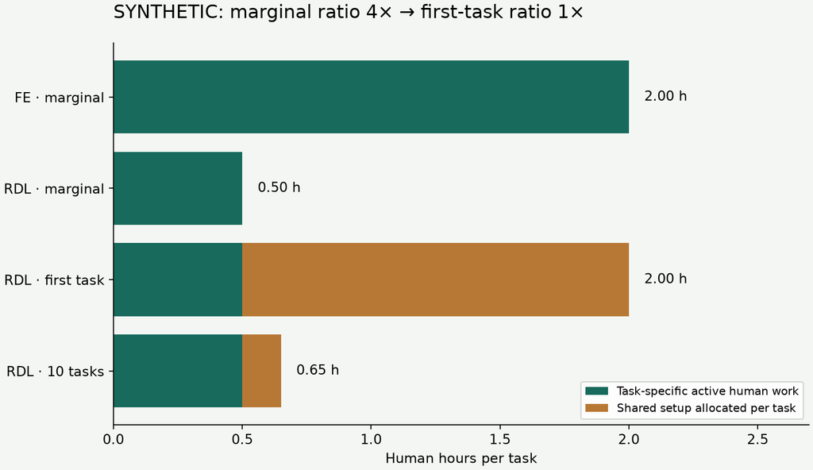

Synthetic accounting example only. Marginal human work, allocated shared setup and machine runtime answer different questions. No human hours were measured for the actual F1 runs.

**Worked example, synthetic.** FE needs 2 hours of active task work; RDL needs 0.5 hours. The marginal ratio is `2 / 0.5 = 4×`. RDL uses `100 × (1 − 0.5 / 2) = 75%` less active time. If RDL also needs 1.5 hours of shared setup and FE has none in this example, first-task total effort is 2 hours for each: ratio 1×. Spreading that setup across 10 tasks gives 0.65 hours per RDL task and about 3.08×. All three statements can be arithmetically correct; they answer different questions.

The denominator changes as reusable setup is amortized. Keep the same synthetic inputs and make the accounting explicit:

| Task count N | FE hours / task | RDL hours / task | FE / RDL |
| --- | --- | --- | --- |
| 1 | 2 | .5 + 1.5 = 2 | 1× |
| 2 | 2 | .5 + .75 = 1.25 | 1.6× |
| 10 | 2 | .5 + .15 = .65 | 3.08× |

Here RDL total human time is `1.5 + .5N`, so its per-task cost is `.5 + 1.5/N`. The marginal-only 4× ratio is approached as setup is spread over many tasks; it is not the first-task result. **Try it:** if FE also needs 1 hour of shared setup, recompute the first-task ratio. **Check:** `(1+2)/(1.5+.5)=1.5×`. Machine time still belongs in its own column, and these invented hours must never enter the measured report.

Predict before interacting: if the accuracy values stay fixed, can including shared setup change the apparent effort advantage?

Try the synthetic fixture in the CHECK cell: FE2h, RDL.5h marginal and1.5h shared; marginal ratio4×, first-task total1×.

**Lab task 2 — `summarize_effort`.** Validate timezone-aware closed sessions. Separate human marginal hours, human shared hours and machine hours. Reject duplicate IDs, overlapping active human intervals, mixed task/participant/assistance policies and unsupported completeness claims. Coverage has three states: complete, partial, or not observed. An empty log is missing evidence, never zero effort.

**Lab task 3 — `effort_ratio`.** Require two complete observed marginal-human totals and positive denominators. Return a missing ratio for incomplete or absent evidence. Explain why a 4× ratio corresponds to 75% less time, not 400% less time.

```python
# TODO: live report/effort contract.
def summarize_effort(sessions, task, participant, assistance, coverage):
    """Count human marginal time separately from shared setup and machine time."""
    if not task or not participant or not assistance:raise ValueError('Declare task, participant and assistance')
    if set(coverage)!={'FE','RDL'} or any(v not in {'complete','partial','not_observed'} for v in coverage.values()):raise ValueError('Explicit method coverage required')
    marginal=dict(FE=0.,RDL=0.);shared=dict(FE=0.,RDL=0.);machine=dict(FE=0.,RDL=0.)
    seen=set();human_intervals=[];observed=set()
    for s in sessions:
        if not s.get('id') or s['id'] in seen:raise ValueError('Distinct session IDs required')
        seen.add(s['id'])
        if (s.get('task'),s.get('participant'),s.get('assistance'))!=(task,participant,assistance):raise ValueError('Mixed task, participant or assistance policy')
        method=s.get('method');kind=s.get('kind');scope=s.get('scope')
        if method not in marginal or kind not in {'human','machine'} or scope not in {'marginal','shared'} or not s.get('phase'):raise ValueError('Invalid session contract')
        try:
            start=datetime.fromisoformat(s['start']);end=datetime.fromisoformat(s['end'])
            if start.utcoffset() is None or end.utcoffset() is None or end<=start:raise ValueError('Closed positive interval with timezone required')
        except (KeyError,TypeError):raise ValueError('Closed timestamp interval required')
        hours=(end-start).total_seconds()/3600
        if kind=='human':
            if any(start<b and a<end for a,b in human_intervals):raise ValueError('Overlapping active human sessions')
            human_intervals.append((start,end))
            (marginal if scope=='marginal' else shared)[method]+=hours
            if scope=='marginal':observed.add(method)
        else:machine[method]+=hours
    for method,status in coverage.items():
        if status=='complete' and method not in observed:raise ValueError('Complete effort requires observed marginal human sessions')
        if status=='not_observed' and method in observed:raise ValueError('Observed sessions conflict with missingness')
        if method not in observed:marginal[method]=None
    return dict(task=task,participant=participant,assistance=assistance,coverage=dict(coverage),
                human_marginal_hours=marginal,human_shared_hours=shared,machine_hours=machine,
                interpretation='Descriptive logged effort; completeness is self-attested; order and experience are not controlled')
```

```python
# CHECK: synthetic boundary cases, not observed human data.
def rejects(call):
    try:call()
    except (ValueError,TypeError):return
    raise AssertionError('Invalid evidence was accepted')
def fixture():
    common=dict(task='demo',participant='learner',assistance='none',kind='human',scope='marginal',phase='feature_implementation')
    return [dict(common,id='a',method='FE',start='2026-10-01T08:00:00+00:00',end='2026-10-01T10:00:00+00:00'),
            dict(common,id='b',method='RDL',start='2026-10-01T11:00:00+00:00',end='2026-10-01T11:30:00+00:00'),
            dict(common,id='c',method='RDL',scope='shared',phase='setup',start='2026-10-01T12:00:00+00:00',end='2026-10-01T13:30:00+00:00'),
            dict(common,id='d',method='FE',kind='machine',phase='training',start='2026-10-01T09:00:00+00:00',end='2026-10-01T12:00:00+00:00')]
def check_effort(fn):
    coverage={'FE':'complete','RDL':'complete'}
    invoke=lambda ss,c=coverage:fn(ss,'demo','learner','none',c)
    r=invoke(fixture());assert r['human_marginal_hours']=={'FE':2.,'RDL':.5}
    assert r['human_shared_hours']=={'FE':0.,'RDL':1.5} and r['machine_hours']['FE']==3
    absent=invoke([],{'FE':'not_observed','RDL':'not_observed'});assert absent['human_marginal_hours']=={'FE':None,'RDL':None}
    rejects(lambda:invoke([],coverage))
    for field,value in [('end',None),('end','2026-10-01T07:00:00+00:00'),('start','2026-10-01T08:00:00'),('assistance','agent'),('scope','unknown'),('kind','agent'),('phase',''),('task','other')]:
        bad=fixture();bad[0][field]=value;rejects(lambda:invoke(bad))
    bad=fixture();bad[1]['start']='2026-10-01T09:00:00+00:00';rejects(lambda:invoke(bad))
    rejects(lambda:invoke(fixture()+[fixture()[0]]))
    partial=invoke(fixture(),{'FE':'partial','RDL':'complete'});assert partial['coverage']['FE']=='partial'
check_effort(summarize_effort)
print("PASS summarize_effort")
```

```
PASS summarize_effort
```

```python
# TODO: live report/effort contract.
def effort_ratio(summary):
    """Ratio needs two complete comparable human logs and a positive denominator."""
    hours=summary['human_marginal_hours']
    for value in hours.values():
        if value is not None and (not math.isfinite(value) or value<0):raise ValueError('Finite nonnegative human hours required')
    if any(v!='complete' for v in summary['coverage'].values()):
        return dict(status='NOT_OBSERVED' if all(v=='not_observed' for v in summary['coverage'].values()) else 'INCOMPLETE',ratio=None,reduction_percent=None)
    fe=hours['FE'];rdl=hours['RDL']
    if fe is None or rdl is None:return dict(status='NOT_OBSERVED',ratio=None,reduction_percent=None)
    if rdl==0 or fe==0:return dict(status='UNDEFINED_ZERO_TIME',ratio=None,reduction_percent=None)
    return dict(status='OBSERVED_DESCRIPTIVE',ratio=fe/rdl,reduction_percent=100*(1-rdl/fe))
```

```python
# CHECK: synthetic boundary cases, not observed human data.
def rejects(call):
    try:call()
    except (ValueError,TypeError):return
    raise AssertionError('Invalid evidence was accepted')
def fixture():
    common=dict(task='demo',participant='learner',assistance='none',kind='human',scope='marginal',phase='feature_implementation')
    return [dict(common,id='a',method='FE',start='2026-10-01T08:00:00+00:00',end='2026-10-01T10:00:00+00:00'),
            dict(common,id='b',method='RDL',start='2026-10-01T11:00:00+00:00',end='2026-10-01T11:30:00+00:00'),
            dict(common,id='c',method='RDL',scope='shared',phase='setup',start='2026-10-01T12:00:00+00:00',end='2026-10-01T13:30:00+00:00'),
            dict(common,id='d',method='FE',kind='machine',phase='training',start='2026-10-01T09:00:00+00:00',end='2026-10-01T12:00:00+00:00')]
def check_ratio(fn):
    base=dict(task='demo',participant='learner',assistance='none',coverage={'FE':'complete','RDL':'complete'},human_marginal_hours={'FE':2.,'RDL':.5})
    assert fn(base)==dict(status='OBSERVED_DESCRIPTIVE',ratio=4.,reduction_percent=75.)
    for hours in [{'FE':None,'RDL':None},{'FE':2.,'RDL':0.}]:
        x=copy.deepcopy(base);x['human_marginal_hours']=hours;assert fn(x)['ratio'] is None
    x=copy.deepcopy(base);x['coverage']['FE']='partial';assert fn(x)['status']=='INCOMPLETE'
    x=copy.deepcopy(base);x['human_marginal_hours']['FE']=-1.;rejects(lambda:fn(x))
    x=copy.deepcopy(base);x['human_marginal_hours']['FE']=float('nan');rejects(lambda:fn(x))
check_ratio(effort_ratio)
print("PASS effort_ratio")
```

```
PASS effort_ratio
```

## 5 · Log prospectively, then write the claim you can defend

**Prospective** means recording sessions as the work happens, rather than estimating old hours after seeing a favorable result. The notebook writes a blank JSON log and shows how to add closed sessions. Record task, method, participant, assistance policy, phase, marginal/shared scope, human/machine kind, start and end. Pause human logging while computation runs unattended. Record active debugging and validation work, not only successful feature edits. Declare your finish criterion before either arm—for example, a complete validated prediction packet under its fixed protocol.

Record assistance explicitly: unaided, documentation-only, or agent-assisted under the same declared policy. Agent generation time is not a human session. Reading or adapting an existing SQL solution measures adaptation effort, not independent feature ideation. If you learned the database while doing FE first, the later RDL attempt benefits from that knowledge. A personal comparison is descriptive and order-confounded; it does not recreate the expert study or establish a population-wide productivity effect. To study that effect, use a separately planned human protocol with comparable expertise, task allocation and order controls.

The author log is **NOT_OBSERVED**. No human-hour ratio is supplied for the actual trained models. The synthetic widget teaches arithmetic; the real score table teaches predictive comparison. Combining them would fabricate an accuracy-versus-effort result. Report the two dimensions side by side; do not divide a bounded classification score by hours and average it with regression MAE.

**Named experiment:** `L155 rel-f1/driver-position — released manual-FE pipeline versus basic RDL`. The report replays 12,590 held-out predictions. The complete fresh training gates are separate and off by default; the author has run the primary full-data experiment. Both gates require their documented pinned runtimes: [FE requirements](https://avistian.github.io/relational/labs/requirements-l129-runtime.txt) and [GNN requirements](https://avistian.github.io/relational/labs/requirements-l117-runtime.txt), plus the native GPU wheel recipe in the [Modal operator](https://avistian.github.io/relational/modal/l155_repro.py). The reference notebook repeats the full pipelines for execution validation; those repeats never enter the primary means.

**Author evidence:** all 8,712 labels and 50 engineered fields were independently reconstructed. All 12,590 held-out predictions were rescored; FE tree replay maximum error 0, GNN original-output maximum difference 2.86e-06. Every GNN seed retained 640 nonfinite entries in its first backward gradients. That is an unresolved source behavior, not a clean optimization-health result. The full pipeline results remain reportable with this limitation.

**Budget:** primary GNN worker-body estimate $0.056940; local FE cloud spend $0. Current reserved worker resources plus the $3 overhead allowance total $5.844072, under the $10 aggregate cap. These are resource estimates/reservations, not an itemized invoice. [Budget](https://avistian.github.io/relational/labs/_budget_l155.json).

The separate full GPU notebook gate passed: five additional complete fits, 6,295 independently checked predictions. Excluded from primary means.

The separate full FE notebook gate passed: five additional complete fits, 6,295 independently checked predictions. Excluded from primary means.

The portfolio now has **one matched FE/RDL task**. Classification FE remains NOT_RUN; recommendation remains INCOMPLETE with test NOT_RUN. A result on one F1 task cannot fill the Year 4 requirement for comparisons on at least three tasks. This lesson adds evidence rather than declaring that requirement met.

```python
# PROVIDED: visible full primary report and driver bootstrap.
def make_report(root,manifest,pair=paired_losses,effort=summarize_effort,ratio=effort_ratio):
    root=Path(root)
    for name,digest in manifest['files'].items():
        assert hashlib.sha256((root/name).read_bytes()).hexdigest()==digest,name
    rows=[];query_count=0;all_benefits=[];ids=None
    for seed in range(5):
        froot=root/f'fe/paper/seed-{seed}';groot=root/f'paper/seed-{seed}'
        f=np.load(froot/'predictions.npz');g=np.load(groot/'predictions.npz')
        fr=json.loads((froot/'result.json').read_text());gr=json.loads((groot/'result.json').read_text())
        assert fr['seed']==gr['seed']==seed and fr['trials']==10 and fr['rounds_cap']==2000
        assert len(fr['trace'])==10 and fr['selected_trial']==min(fr['trace'],key=lambda x:(x['val_mae'],x['number']))['number']
        assert gr['epochs']==10 and len(gr['trace'])==10 and all(x['train_queries']==7453 for x in gr['trace'])
        assert gr['selected_epoch']==min(gr['trace'],key=lambda x:x['val_mae'])['epoch']
        for split,n in [('val',499),('test',760)]:
            # Independent labels must agree by key before any prediction comparison.
            truth={(int(e),int(t)):float(y) for e,t,y in zip(f[split+'_entity'],f[split+'_time'],f[split+'_target'])}
            gtruth={(int(e),int(t)):float(y) for e,t,y in zip(g[split+'_entity'],g[split+'_time'],g[split+'_target'])}
            assert len(truth)==len(f[split+'_target'])==len(gtruth)==len(g[split+'_target'])==n and truth==gtruth
            q=[dict(entity=k[0],time=k[1],target=y) for k,y in truth.items()]
            preds=lambda a:[dict(entity=int(e),time=int(t),prediction=float(p)) for e,t,p in zip(a[split+'_entity'],a[split+'_time'],a[split+'_pred'])]
            paired=pair(q,list(reversed(preds(f))),preds(g))
            assert paired['n']==n
            assert abs(paired['fe_mae']-fr['scores'][split])<1e-10
            assert abs(paired['rdl_mae']-gr['scores'][split])<1e-10
            rows.append(dict(seed=seed,split=split,fe_mae=paired['fe_mae'],rdl_mae=paired['rdl_mae'],benefit_mae=paired['benefit_mae']))
            query_count+=n
            if split=='test':
                keys=[(r['entity'],r['time']) for r in paired['rows']]
                if ids is None:ids=keys
                assert ids==keys
                all_benefits.append([r['benefit'] for r in paired['rows']])
    metrics={s:{arm:dict(mean=statistics.mean(r[arm] for r in rows if r['split']==s),sample_sd=statistics.stdev(r[arm] for r in rows if r['split']==s)) for arm in ['fe_mae','rdl_mae','benefit_mae']} for s in ['val','test']}
    # Resample drivers, retaining all their cutoff queries. Conditional on fitted models.
    entity=np.array([k[0] for k in ids]);unique=np.unique(entity);d=np.mean(all_benefits,axis=0)
    sums=np.array([d[entity==i].sum() for i in unique]);counts=np.array([(entity==i).sum() for i in unique]);rng=np.random.default_rng(155)
    draw=rng.integers(0,len(unique),size=(2000,len(unique)))
    means=sums[draw].sum(axis=1)/counts[draw].sum(axis=1)
    interval=np.quantile(means,[.025,.975]).tolist()
    log=json.loads((root/'effort-log.json').read_text())
    observed=effort(log['sessions'],'rel-f1/driver-position','learner','declared_consistently',{'FE':'not_observed','RDL':'not_observed'})
    return dict(status='COMPLETE_SELECTED_COMPUTATIONAL_REPLAY',task='rel-f1/driver-position',metric='MAE',unit='finishing positions',rows=rows,metrics=metrics,
                scored_prediction_rows=query_count*2,unique_test_queries=len(ids),test_drivers=len(unique),
                test_benefit_driver_bootstrap_95=interval,bootstrap_draws=2000,
                bootstrap_scope='Conditional on fitted models/split; driver clusters only, not common race/time or training uncertainty',
                effort=observed,human_effort_ratio=ratio(observed),
                portfolio=dict(matched_tasks=1,classification_fe='NOT_RUN',recommendation='INCOMPLETE; test NOT_RUN'),
                paper_gnn_test_target=4.022,paper_gnn_tolerance=.2,
                paper_gnn_test_verdict='CLOSE' if abs(metrics['test']['rdl_mae']['mean']-4.022)<=.2 else 'OUTSIDE_TOLERANCE',
                figure3_reproduction='NOT_RUN: boosted regression comparator differs',human_study='NOT_RUN',historical_identity='NOT_ESTABLISHED',learner='PENDING_WRITTEN_DEFENSE')

def render_report(r):
    lines=['# L155 · Matched quality and observed effort','', '| Split | FE MAE mean ± seed SD | Basic RDL MAE mean ± seed SD | FE − RDL MAE |','|---|---:|---:|---:|']
    for split,m in r['metrics'].items():
        fmt=lambda arm:f"{m[arm]['mean']:.6f} ± {m[arm]['sample_sd']:.6f}"
        lines.append(f"| {split} | {fmt('fe_mae')} | {fmt('rdl_mae')} | {m['benefit_mae']['mean']:+.6f} |")
    lo,hi=r['test_benefit_driver_bootstrap_95']
    lines+=['',f"Positive benefit favors RDL. Driver-cluster conditional 95% interval: [{lo:+.6f}, {hi:+.6f}].",'',f"{r['scored_prediction_rows']:,} held-out predictions rescored. Five complete runs per method. Seed labels do not create paired random initializations.",'',f"Human effort: **{r['human_effort_ratio']['status']}**. Original human study **NOT_RUN**. One matched task; classification FE and recommendation test remain missing.",'', 'Basic GNN targets Table7; it is not Figure3 boosted regression. Historical identity and feature-arrival legality NOT_ESTABLISHED. Learner PENDING_WRITTEN_DEFENSE.']
    return '\n'.join(lines)+'\n'
```

```python
# CHECK: actual evidence flows through your three functions.
report=make_report(REPLAY_ROOT,MANIFEST,pair=paired_losses,effort=summarize_effort,ratio=effort_ratio)
assert report['scored_prediction_rows']==12590
assert report['human_effort_ratio']['status']=='NOT_OBSERVED'
display(Markdown(render_report(report)))
```

L155 · Matched quality and observed effort

| Split | FE MAE mean ± seed SD | Basic RDL MAE mean ± seed SD | FE − RDL MAE |
| --- | --- | --- | --- |
| val | 2.777330 ± 0.027905 | 3.168988 ± 0.030376 | -0.391658 |
| test | 3.948917 ± 0.070469 | 4.013141 ± 0.208250 | -0.064225 |

Positive benefit favors RDL. Driver-cluster conditional 95% interval: [-0.312329, +0.172961].

12,590 held-out predictions rescored. Five complete runs per method. Seed labels do not create paired random initializations.

Human effort: **NOT_OBSERVED**. Original human study **NOT_RUN**. One matched task; classification FE and recommendation test remain missing.

Basic GNN targets Table7; it is not Figure3 boosted regression. Historical identity and feature-arrival legality NOT_ESTABLISHED. Learner PENDING_WRITTEN_DEFENSE.

## 6 · Exit: defend both the measured result and the empty cell

[Student notebook](https://avistian.github.io/relational/labs/0155-compare-manual-fe.ipynb) · [Worked notebook](https://avistian.github.io/relational/labs/html/0155-compare-manual-fe.html) · [Teacher solution](https://avistian.github.io/relational/labs/solutions/0155-compare-manual-fe.ipynb) · [Report](https://avistian.github.io/relational/labs/evidence/l155/report.md) · [Reference](https://avistian.github.io/relational/reference/compare-manual-fe.html) · [Reproduction contract](https://avistian.github.io/relational/labs/l155-reproduction.md).

Export your regenerated quality report and either a validated real effort log or an explicit NOT_OBSERVED result. Write 250–400 words explaining: what was held fixed, the direction and units of the measured quality difference, what the uncertainty interval covers, which effort clock matches the paper, and what remains missing from the thesis claim. Include the Figure 3/basic-GNN distinction.

Review rubric: query comparability, computation, effort accounting, evidence boundaries and conclusion—0–2 points each; readiness requires 8/10 with no zero, reviewed by the teaching agent. Author execution leaves **PENDING_WRITTEN_DEFENSE**. Tomorrow reconstruct 4× versus 75% without notes. In one week, audit an effort log containing an overlapping session and missing task work.

Explain why a full training reproduction can coexist with unmeasured human effort before consulting the teacher.

Ask the agent follow-up questions about any unclear join, time category or reproduction boundary. [Lesson 156](https://avistian.github.io/relational/lessons/0156-temporal-leakage-audit.html) will audit temporal leakage across the pipeline; today's missing arrival histories remain a question for that audit, not a solved problem.

### PROVIDED · Your prospective effort log

Edit the JSON file after a real session, then rerun this cell. Each session has `id`, `task`, `participant`, `assistance`, `method`(FE/RDL), `phase`, `kind`(human/machine), `scope`(marginal/shared), `start` and `end`(ISO8601 with timezone). Set coverage to partial while work remains. Attest complete only after the declared finish criterion is met. Use the same assistance policy in both arms. Do not copy synthetic CHECK sessions into your real log.

```python
log_path=Path('l155-my-effort.json')
if not log_path.exists():
    log_path.write_text(json.dumps(dict(task='rel-f1/driver-position',participant='YOUR_NAME',assistance='DECLARE_POLICY',coverage={'FE':'not_observed','RDL':'not_observed'},sessions=[]),indent=2))
my_log=json.loads(log_path.read_text())
my_effort=summarize_effort(my_log['sessions'],my_log['task'],my_log['participant'],my_log['assistance'],my_log['coverage'])
my_ratio=effort_ratio(my_effort)
print('Your logged evidence:',my_ratio)
```

```
Your logged evidence: {'status': 'NOT_OBSERVED', 'ratio': None, 'reduction_percent': None}
```

```python
# EXIT: human reasoning is reviewed separately from code execution.
WRITTEN_DEFENSE=""  # 250–400 words; submit to the teaching agent.
export=dict(report,personal_effort=my_effort,personal_ratio=my_ratio,written_defense=WRITTEN_DEFENSE)
Path('l155-comparison.json').write_text(json.dumps(export,indent=2))
Path('l155-comparison.md').write_text(render_report(report)+'\n'+WRITTEN_DEFENSE)
print('Exported comparison; learner PENDING_WRITTEN_DEFENSE')
```

```
Exported comparison; learner PENDING_WRITTEN_DEFENSE
```

## Post-EXIT · Full released computational reproduction

FE and GNN use different historical dependency stacks. Run each gate in its own empty working directory with its pinned requirements. Use `RUN_FULL_FE_REPRODUCTION` or `RUN_FULL_GNN_REPRODUCTION` in the bootstrap cell. The Modal operator contains the GPU image recipe and author budget guard. Notebook gates do not enforce spending limits. FE needs Python3.11, Torch2.2.2, Frame0.2.2 and LightGBM4.3.0; GNN needs Torch2.5.1/CUDA12.4, Frame0.2.3, PyG2.6.1 and native pyg-lib. Full requirements and all deviations are in the reproduction ledger. Source definitions below are visible; payload cells transport original source/data for offline FE execution.

### PROVIDED · Released SQL and full FE pipeline

Original user-study commit445bb7a3b1230f49f8e5890ae81754d3e365680f. SQL and schema are supplied verbatim with attribution; no new license is asserted. Frame search code is MIT. Full query rows, train-fitted mappings, ten-trial search and selected refit remain visible.

```
create or replace table driver_position_{{ set }}_feats as -- noqa

with labels as materialized (
    -- driverId, date, position
    {% if (set == 'train') and (subsample > 0) %} -- noqa
    select * from driver_position_{{ set }} using sample {{ subsample }} -- noqa
    {% else %}
    select * from driver_position_{{ set }} -- noqa
    {% endif %}
),

standings2 as (
    select
        *,
        points - lag(points, 1) over (partition by raceId order by position asc) as points_lag,
        points - lead(points, 1) over (partition by raceId order by position asc) as points_lead
    from standings
),

constructor_standings2 as (
    select
        *,
        points - lag(points, 1) over (partition by raceId order by position asc) as points_lag,
        points - lead(points, 1) over (partition by raceId order by position asc) as points_lead
    from constructor_standings
),

-- results has duplicates
results_dd as materialized (
    select distinct on (raceId, driverId)
        raceId,
        driverId,
        constructorId,
        position,
        points,
        grid,
        rank,
        laps,
        statusId,
        date
    from results
),

basic_feats as (
    select
        labels.driverId,
        labels.date,
        date_part('week', labels.date) as week_of_year,
        -- driver features
        drivers.driverRef as driver_ref, -- use as categorical
        date_diff('year', drivers.dob::date, labels.date) as driver_age,
        drivers.nationality as driver_nationality,
        -- driver standings
        standings2.position as driver_position,
        standings2.points as driver_points,
        standings2.wins as driver_wins,
        standings2.points_lag as driver_points_lag,
        standings2.points_lead as driver_points_lead,
        date_diff('day', standings2.date, labels.date) as days_since_last_race,
        -- constructor features
        constructors.constructorRef as constructor_ref,
        constructors.nationality as constructor_nationality,
        -- constructor standings
        constructor_standings2.position as constructor_position,
        constructor_standings2.points as constructor_points,
        constructor_standings2.wins as constructor_wins,
        constructor_standings2.points_lag as constructor_points_lag,
        constructor_standings2.points_lead as constructor_points_lead,
        -- driver contribution
        driver_position - constructor_position as position_diff,
        driver_points / nullif(constructor_points, 0) as points_ratio,
        driver_wins / nullif(constructor_wins, 0) as wins_ratio
    from labels
    left join drivers
        on labels.driverId = drivers.driverId
    asof left join standings2
        on
            labels.driverId = standings2.driverId
            and labels.date > standings2.date
    left join results_dd -- use it to join constructor_standings
        on
            standings2.raceId = results_dd.raceId
            and labels.driverId = results_dd.driverId
    left join constructor_standings2
        on
            standings2.raceId = constructor_standings2.raceId
            and results_dd.constructorId = constructor_standings2.constructorId
    left join constructors
        on constructor_standings2.constructorId = constructors.constructorId
),

past_race_features as (
    select
        labels.driverId,
        labels.date,
        (last_race.raceId - results_dd.raceId + 1) as races_ago,
        -- results_dd
        results_dd.position as driver_position,
        results_dd.points as driver_points,
        results_dd.grid as driver_grid,
        results_dd.position - results_dd.grid as position_gain,
        results_dd.rank as driver_rank,
        results_dd.laps
        / max(results_dd.laps) over (partition by results_dd.raceId) as pct_laps_completed,
        (results_dd.statusId != 1)::int as dnf,
        -- constructor results_dd
        constructor_results.points as constructor_points
    from labels
    asof left join races as last_race
        on labels.date > last_race.date
    left join results_dd
        on
            labels.driverId = results_dd.driverId
            and (last_race.raceId - results_dd.raceId) between 0 and 2 -- last 3 races
            -- exclude races from last season
            and results_dd.date >= (labels.date - interval '2 month')
    left join constructor_results
        on
            results_dd.raceId = constructor_results.raceId
            and results_dd.constructorId = constructor_results.constructorId
),

upcoming_race_features as (
    select
        labels.driverId,
        labels.date,
        (upcoming.raceId - last_race.raceId) as races_ahead,
        upcoming.round,
        circuits.circuitId
    from labels
    asof left join races as last_race
        on labels.date > last_race.date
    left join races as upcoming
        on
            (upcoming.raceId - last_race.raceId) between 1 and 3 -- next 3 races
            and upcoming.date <= (labels.date + interval '1 month')
    left join circuits
        on upcoming.circuitId = circuits.circuitId
)

select
    labels.driverId,
    labels.date,
    {% if set != 'test' +%} -- noqa
        labels.position,
    {% endif %}
    basic_feats.* exclude(driverId, date),
    {% for i in [1, 2, 3] %}
        past_{{ i }}.driver_position as past_{{ i }}_driver_position,
        past_{{ i }}.driver_points as past_{{ i }}_driver_points,
        past_{{ i }}.driver_grid as past_{{ i }}_driver_grid,
        past_{{ i }}.position_gain as past_{{ i }}_position_gain,
        past_{{ i }}.driver_rank as past_{{ i }}_driver_rank,
        past_{{ i }}.pct_laps_completed as past_{{ i }}_pct_laps_completed,
        past_{{ i }}.dnf as past_{{ i }}_dnf,
        past_{{ i }}.constructor_points as past_{{ i }}_constructor_points,
        upcoming_{{ i }}.round as upcoming_{{ i }}_round,
        upcoming_{{ i }}.circuitId as upcoming_{{ i }}_circuit_id
        {%- if not loop.last %},{% endif %} -- noqa
    {% endfor %}
from labels
left join basic_feats
    on
        labels.driverId = basic_feats.driverId
        and labels.date = basic_feats.date
{% for i in [1, 2, 3] %}
    left join past_race_features as past_{{ i }}
        on
            labels.driverId = past_{{ i }}.driverId
            and labels.date = past_{{ i }}.date
            and past_{{ i }}.races_ago = {{ i }}
    left join upcoming_race_features as upcoming_{{ i }}
        on
            labels.driverId = upcoming_{{ i }}.driverId
            and labels.date = upcoming_{{ i }}.date
            and upcoming_{{ i }}.races_ahead = {{ i }}
{% endfor %}
```

```python
if RUN_FULL_FE_REPRODUCTION:
    import importlib.metadata as md
```

```python
if RUN_FULL_FE_REPRODUCTION:
    for package,version in {'torch':'2.2.2','pytorch-frame':'0.2.2','lightgbm':'4.3.0','optuna':'3.6.1','duckdb':'0.10.3','pandas':'2.0.3','numpy':'1.26.0','jinja2':'3.1.3'}.items():
     assert md.version(package)==version, (package,'use requirements-l129-runtime.txt')
```

```python
if RUN_FULL_FE_REPRODUCTION:
    """Complete released manual-feature experiment, with explicit reproducibility adapters.

    SQL: snap-stanford/relbench-user-study 445bb7a3b1230f49f8e5890ae81754d3e365680f.
    LightGBM search mirrors pytorch-frame 0.2.2 (MIT, license in sources/l129/frame).
    No subsampling. Archive loader replaces unavailable historical staging endpoints.
    """
```

```python
if RUN_FULL_FE_REPRODUCTION:
    import hashlib,io,json,time,zipfile
```

```python
if RUN_FULL_FE_REPRODUCTION:
    from pathlib import Path
```

```python
if RUN_FULL_FE_REPRODUCTION:
    import numpy as np
```

```python
if RUN_FULL_FE_REPRODUCTION:
    import pandas as pd
```

```python
if RUN_FULL_FE_REPRODUCTION:
    import pyarrow.parquet as pq
```

```python
if RUN_FULL_FE_REPRODUCTION:
    import duckdb
```

```python
if RUN_FULL_FE_REPRODUCTION:
    from jinja2 import Template
```

```python
if RUN_FULL_FE_REPRODUCTION:
    KEYS=['driverId','date']
```

```python
if RUN_FULL_FE_REPRODUCTION:
    def load_archives(source):
        source=Path(source)
        for spec in json.loads((source/'data-manifest.json').read_text()):
            assert hashlib.sha256((source/spec['path']).read_bytes()).hexdigest()==spec['sha256']
        tables={};raw_counts={}
        with zipfile.ZipFile(source/'db.zip') as z:
            for name in z.namelist():
                if not name.endswith('.parquet'):continue
                table=pq.read_table(io.BytesIO(z.read(name)),use_threads=False)
                df=table.to_pandas();time_col=json.loads(table.schema.metadata[b'time_col'])
                raw_counts[Path(name).stem]=len(df)
                if time_col is not None:df=df[df[time_col]<=pd.Timestamp('2010-01-01')]
                tables[Path(name).stem]=df.reset_index(drop=True)
        with zipfile.ZipFile(source/'driver-position.zip') as z:
            labels={s:pq.read_table(io.BytesIO(z.read(f'driver-position/{s}.parquet')),use_threads=False).to_pandas() for s in ['train','val','test']}
        return tables,labels,raw_counts
```

```python
if RUN_FULL_FE_REPRODUCTION:
    def make_features(tables,labels,sql,threads=4):
        con=duckdb.connect();con.execute(f'SET threads={int(threads)}')
        for name,df in tables.items():
            con.register('incoming',df);con.execute(f'CREATE TABLE "{name}" AS SELECT * FROM incoming')
        for split,df in labels.items():
            # Keep final test targets outside feature SQL entirely.
            if split=='test':df=df.drop(columns=['position'])
            con.register('incoming',df);con.execute(f'CREATE TABLE driver_position_{split} AS SELECT * FROM incoming')
            con.execute(Template(sql).render(set=split,subsample=0))
        features={s:con.sql(f'SELECT * FROM driver_position_{s}_feats').df() for s in labels}
        con.close()
        for split,df in features.items():
            assert len(df)==len(labels[split]) and not df.duplicated(KEYS).any()
            assert set(map(tuple,df[KEYS].to_numpy()))==set(map(tuple,labels[split][KEYS].to_numpy()))
            # SQL has no ORDER BY: freeze archive query order before seeded sampling.
            order=pd.MultiIndex.from_frame(labels[split][KEYS])
            features[split]=df.set_index(KEYS).loc[order].reset_index()
        return features
```

```python
if RUN_FULL_FE_REPRODUCTION:
    def materialize_features(features,stypes):
        from torch_frame.data import Dataset
        from torch_frame.gbdt import LightGBM
        from torch_frame import TaskType,Metric
        dataset=Dataset(features['train'],col_to_stype=stypes,target_col='position').materialize()
        model=LightGBM(TaskType.REGRESSION,metric=Metric.MAE)
        frames={s:dataset.tensor_frame if s=='train' else dataset.convert_to_tensor_frame(df) for s,df in features.items()}
        matrices={s:model._to_lightgbm_input(tf) for s,tf in frames.items()}
        return dataset,frames,matrices
```

```python
if RUN_FULL_FE_REPRODUCTION:
    def sample_parameters(trial):
        return dict(verbosity=-1,bagging_freq=1,
            max_depth=trial.suggest_int('max_depth',3,11),
            learning_rate=trial.suggest_float('learning_rate',1e-3,.1,log=True),
            num_leaves=trial.suggest_int('num_leaves',2,2**10),
            subsample=trial.suggest_float('subsample',.05,1.),
            colsample_bytree=trial.suggest_float('colsample_bytree',.05,1.),
            lambda_l1=trial.suggest_float('lambda_l1',1e-9,10.,log=True),
            lambda_l2=trial.suggest_float('lambda_l2',1e-9,10.,log=True),
            min_data_in_leaf=trial.suggest_int('min_data_in_leaf',1,100),
            objective='regression_l1',metric='mae')
```

```python
if RUN_FULL_FE_REPRODUCTION:
    def tune_fe(matrices,seed,num_trials=10,rounds=2000,threads=4):
        import lightgbm as lgb
        import optuna
        train_x,train_y,cats=matrices['train'];val_x,val_y,_=matrices['val']
        train=lgb.Dataset(train_x,label=train_y,free_raw_data=False)
        val=lgb.Dataset(val_x,label=val_y,free_raw_data=False)
        trace=[]
        study=optuna.create_study(direction='minimize',sampler=optuna.samplers.TPESampler(seed=seed))
        def fit(params):
            return lgb.train(dict(params,num_threads=threads),train,num_boost_round=rounds,
                categorical_feature=cats,valid_sets=[val],callbacks=[lgb.early_stopping(50,verbose=False),lgb.log_evaluation(0)])
        def objective(trial):
            start=time.perf_counter();params=sample_parameters(trial);model=fit(params)
            pred=model.predict(val_x);score=float(np.mean(np.abs(pred-val_y)))
            trace.append(dict(number=trial.number,val_mae=score,best_iteration=model.best_iteration,params=params,seconds=time.perf_counter()-start))
            return score
        study.optimize(objective,n_trials=num_trials)
        selected=choose_trial(trace);assert selected==study.best_trial.number
        best=next(row for row in trace if row['number']==selected)
        model=fit(best['params']) # upstream refits the selected configuration
        assert abs(float(np.mean(np.abs(model.predict(val_x)-val_y)))-best['val_mae'])<1e-10
        return model,trace,selected
```

```python
if RUN_FULL_FE_REPRODUCTION:
    def choose_trial(trials):
        if not trials or len({r['number'] for r in trials}) != len(trials):
            raise ValueError('need complete unique trials')
        if not all(math.isfinite(r['val_mae']) and r['val_mae'] >= 0 for r in trials):
            raise ValueError('invalid validation MAE')
        return min(trials, key=lambda r: (r['val_mae'], r['number']))['number']
```

```python
if RUN_FULL_FE_REPRODUCTION:
    def align_predictions(feature_keys, predictions, query_keys):
        feature_keys = [tuple(k) for k in feature_keys]
        query_keys = [tuple(k) for k in query_keys]
        if len(feature_keys) != len(predictions):
            raise ValueError('one prediction per feature row required')
        if len(set(feature_keys)) != len(feature_keys) or len(set(query_keys)) != len(query_keys):
            raise ValueError('duplicate query keys')
        if set(feature_keys) != set(query_keys):
            raise ValueError('query key sets differ')
        if not all(math.isfinite(float(p)) for p in predictions):
            raise ValueError('nonfinite prediction')
        mapping = dict(zip(feature_keys, predictions))
        return [float(mapping[k]) for k in query_keys]
```

```python
if RUN_FULL_FE_REPRODUCTION:
 tables,queries,_=load_archives(source)
 features=make_features(tables,queries,(source/'f1/driver-position/feats.sql').read_text())
 spec=importlib.util.spec_from_file_location('types',source/'inferred_stypes.py');types=importlib.util.module_from_spec(spec);spec.loader.exec_module(types)
 dataset,frames,matrices=materialize_features(features,types.task_to_stypes['rel-f1-driver-position'])
 output=Path('l155-fe-full');output.mkdir(exist_ok=False);records=[]
 for seed in range(5):
  model,trace,chosen=tune_fe(matrices,seed,num_trials=10,rounds=2000,threads=4)
  model.save_model(str(output/f'seed-{seed}.txt'));scores={};saved={}
  for split in ['val','test']:
   q=queries[split];df=features[split];keys=list(zip(q.driverId,q.date))
   pred=np.array(align_predictions(list(zip(df.driverId,df.date)),model.predict(matrices[split][0]),keys));target=q.position.to_numpy()
   scores[split]=float(np.mean(np.abs(pred-target)))
   saved.update({split+'_pred':pred,split+'_target':target,split+'_entity':q.driverId.to_numpy(),split+'_time':q.date.astype('int64').to_numpy()})
  np.savez_compressed(output/f'seed-{seed}.npz',**saved)
  record=dict(seed=seed,trace=trace,selected_trial=chosen,scores=scores);records.append(record)
  (output/f'seed-{seed}.json').write_text(json.dumps(record,indent=2))
 (output/'packet.json').write_text(json.dumps(dict(status='PASS',fits=5,trials=50,records=records),indent=2))
 print('Full FE reproduction:50 trials and5 refits completed')
```

### PROVIDED · Basic RDL computation

Read in order: key identity → typed row encoders and graph convolutions → scalar head → graph construction → validation-selected full trainer. These are the same definitions used in the primary GNN lane.

```python
if RUN_FULL_GNN_REPRODUCTION:
    """Regression portfolio contracts: pure NumPy, live in both notebook lanes."""
    import math
    import statistics
    import numpy as np

    def keyed_metrics(queries, predictions):
        """Join complete unique (entity,time) sets; bias means prediction minus target."""
        q={(r['entity'],r['time']):float(r['target']) for r in queries}
        p={(r['entity'],r['time']):float(r['prediction']) for r in predictions}
        if not q or len(q)!=len(queries) or len(p)!=len(predictions) or q.keys()!=p.keys():
            raise ValueError('Require identical nonempty unique query keys')
        if not all(math.isfinite(x) for x in list(q.values())+list(p.values())):
            raise ValueError('Nonfinite target or prediction')
        residual=np.array([p[k]-q[k] for k in sorted(q)],dtype=float)
        return dict(n=len(q),mae=float(np.mean(np.abs(residual))),rmse=float(np.sqrt(np.mean(residual**2))),bias=float(np.mean(residual)))

    def median_diagnostics(target, prediction, edges):
        """Fixed prediction bins; ties satisfy both median inequalities.

        Bins are [-inf,e0),[e0,e1),...,[elast,inf). Mean residual is y-p.
        This finite-sample diagnostic does not certify population calibration.
        """
        y=np.asarray(target,dtype=float);p=np.asarray(prediction,dtype=float);e=np.asarray(edges,dtype=float)
        if y.ndim!=1 or p.ndim!=1 or e.ndim!=1 or len(y)!=len(p) or not len(y):raise ValueError('Aligned nonempty vectors required')
        if not all(np.isfinite(x).all() for x in [y,p,e]) or np.any(np.diff(e)<=0):raise ValueError('Finite vectors and strictly increasing edges required')
        group=np.searchsorted(e,p,side='right');rows=[]
        for i in range(len(e)+1):
            mask=group==i;n=int(mask.sum())
            row=dict(bin=i,n=n,prediction_mean=None,below=None,equal=None,above=None,median_violation=None,mean_residual=None)
            if n:
                below=float(np.mean(y[mask]<p[mask]));equal=float(np.mean(y[mask]==p[mask]));above=float(np.mean(y[mask]>p[mask]))
                row.update(prediction_mean=float(p[mask].mean()),below=below,equal=equal,above=above,median_violation=max(0.,below-.5,above-.5),mean_residual=float(np.mean(y[mask]-p[mask])))
            rows.append(row)
        return rows

    def portfolio_summary(records):
        """All five full fits, sample seed SD, and explicitly bounded evidence claims."""
        if len(records)!=5 or {r['seed'] for r in records}!=set(range(5)):raise ValueError('Exactly seeds0–4 required')
        for r in records:
            if r['epochs']!=10 or r['complete'] is not True:raise ValueError('Incomplete fit')
            if any(not math.isfinite(r[k]) or r[k]<0 for k in ['val_mae','test_mae','test_rmse']):raise ValueError('Invalid metric')
        result={}
        for name,key in [('val','val_mae'),('test','test_mae'),('rmse','test_rmse')]:
            values=[r[key] for r in sorted(records,key=lambda r:r['seed'])]
            result[name]=dict(mean=statistics.mean(values),sample_sd=statistics.stdev(values),values=values)
        result.update(paper_score='CLOSE' if abs(result['test']['mean']-4.022)<=.20+8*math.ulp(4.022) else 'OUTSIDE_TOLERANCE',historical_identity='NOT_ESTABLISHED',feature_arrival_legality='NOT_ESTABLISHED',whole_paper='NOT_RUN',fresh_fe_comparison='NOT_RUN',learner='PENDING_WRITTEN_DEFENSE')
        return result
```

```python
if RUN_FULL_GNN_REPRODUCTION:
    # PROVIDED: visible released pipeline stage
    """Visible RDL blueprint and released-protocol model (RelBench MIT license).

    The three learner tasks are deliberately usable with only NumPy. The full
    experiment uses pinned PyTorch Frame / PyG primitives, not a hidden model wrapper.
    """
```

```python
if RUN_FULL_GNN_REPRODUCTION:
    # PROVIDED: visible released pipeline stage
    # %% Key identities (PROVIDED)
    import numpy as np
```

```python
if RUN_FULL_GNN_REPRODUCTION:
    # PROVIDED: visible released pipeline stage
    # %% Task 1: map foreign keys to row positions

    def foreign_key_edges(primary_keys, foreign_keys):
        lookup = {key: i for i, key in enumerate(primary_keys)}
        if len(lookup) != len(primary_keys):
            raise ValueError("Primary keys must be unique")
        pairs = []
        for source, key in enumerate(foreign_keys):
            if key is None or (isinstance(key, float) and np.isnan(key)):
                continue
            if key not in lookup:
                raise ValueError("Unknown foreign key")
            pairs.append((source, lookup[key]))
        return np.asarray(pairs, dtype=np.int64).reshape(-1, 2).T
```

```python
if RUN_FULL_GNN_REPRODUCTION:
    # PROVIDED: visible released pipeline stage
    # %% Task 2: preserve one query cutoff across every hop

    def temporal_nodes(edges, times, seed, cutoff, hops):
        if times[seed] is not None and times[seed] > cutoff:
            raise ValueError("Seed is unavailable at the query time")
        seen, frontier = {seed}, {seed}
        for _ in range(hops):
            candidates = {dst for src, dst in edges if src in frontier
                          and (times[dst] is None or times[dst] <= cutoff)}
            frontier = candidates - seen
            seen |= candidates
        return sorted(seen)
```

```python
if RUN_FULL_GNN_REPRODUCTION:
    # PROVIDED: visible released pipeline stage
    # %% Task 3: attach labels by query identity, not entity identity

    def query_targets(targets, input_id):
        return np.asarray(targets)[np.asarray(input_id, dtype=np.int64)]
```

```python
if RUN_FULL_GNN_REPRODUCTION:
    # PROVIDED: visible released pipeline stage
    # %% Full released model dependencies (PROVIDED)
    from typing import Any, Dict, List, Optional

    import torch
    import torch_frame
    from torch import Tensor
    from torch_frame.data.stats import StatType
    from torch_frame.nn.models import ResNet
    from torch_geometric.nn import HeteroConv, LayerNorm, PositionalEncoding, SAGEConv
    from torch_geometric.typing import EdgeType, NodeType


    class HeteroEncoder(torch.nn.Module):
        r"""HeteroEncoder based on PyTorch Frame.

        Args:
            channels (int): The output channels for each node type.
            node_to_col_names_dict (Dict[NodeType, Dict[torch_frame.stype, List[str]]]):
                A dictionary mapping from node type to column names dictionary
                compatible to PyTorch Frame.
            torch_frame_model_cls: Model class for PyTorch Frame. The class object
                takes :class:`TensorFrame` object as input and outputs
                :obj:`channels`-dimensional embeddings. Default to
                :class:`torch_frame.nn.ResNet`.
            torch_frame_model_kwargs (Dict[str, Any]): Keyword arguments for
                :class:`torch_frame_model_cls` class. Default keyword argument is
                set specific for :class:`torch_frame.nn.ResNet`. Expect it to
                be changed for different :class:`torch_frame_model_cls`.
            default_stype_encoder_cls_kwargs (Dict[torch_frame.stype, Any]):
                A dictionary mapping from :obj:`torch_frame.stype` object into a
                tuple specifying :class:`torch_frame.nn.StypeEncoder` class and its
                keyword arguments :obj:`kwargs`.
        """

        def __init__(
            self,
            channels: int,
            node_to_col_names_dict: Dict[NodeType, Dict[torch_frame.stype, List[str]]],
            node_to_col_stats: Dict[NodeType, Dict[str, Dict[StatType, Any]]],
            torch_frame_model_cls=ResNet,
            torch_frame_model_kwargs: Dict[str, Any] = {
                "channels": 128,
                "num_layers": 4,
            },
            default_stype_encoder_cls_kwargs: Dict[torch_frame.stype, Any] = {
                torch_frame.categorical: (torch_frame.nn.EmbeddingEncoder, {}),
                torch_frame.numerical: (torch_frame.nn.LinearEncoder, {}),
                torch_frame.multicategorical: (
                    torch_frame.nn.MultiCategoricalEmbeddingEncoder,
                    {},
                ),
                torch_frame.embedding: (torch_frame.nn.LinearEmbeddingEncoder, {}),
                torch_frame.timestamp: (torch_frame.nn.TimestampEncoder, {}),
            },
        ):
            super().__init__()

            self.encoders = torch.nn.ModuleDict()

            for node_type in node_to_col_names_dict.keys():
                stype_encoder_dict = {
                    stype: default_stype_encoder_cls_kwargs[stype][0](
                        **default_stype_encoder_cls_kwargs[stype][1]
                    )
                    for stype in node_to_col_names_dict[node_type].keys()
                }
                torch_frame_model = torch_frame_model_cls(
                    **torch_frame_model_kwargs,
                    out_channels=channels,
                    col_stats=node_to_col_stats[node_type],
                    col_names_dict=node_to_col_names_dict[node_type],
                    stype_encoder_dict=stype_encoder_dict,
                )
                self.encoders[node_type] = torch_frame_model

        def reset_parameters(self):
            for encoder in self.encoders.values():
                encoder.reset_parameters()

        def forward(
            self,
            tf_dict: Dict[NodeType, torch_frame.TensorFrame],
        ) -> Dict[NodeType, Tensor]:
            x_dict = {
                node_type: self.encoders[node_type](tf) for node_type, tf in tf_dict.items()
            }
            return x_dict


    class HeteroTemporalEncoder(torch.nn.Module):
        def __init__(self, node_types: List[NodeType], channels: int):
            super().__init__()

            self.encoder_dict = torch.nn.ModuleDict(
                {node_type: PositionalEncoding(channels) for node_type in node_types}
            )
            self.lin_dict = torch.nn.ModuleDict(
                {node_type: torch.nn.Linear(channels, channels) for node_type in node_types}
            )

        def reset_parameters(self):
            for encoder in self.encoder_dict.values():
                encoder.reset_parameters()
            for lin in self.lin_dict.values():
                lin.reset_parameters()

        def forward(
            self,
            seed_time: Tensor,
            time_dict: Dict[NodeType, Tensor],
            batch_dict: Dict[NodeType, Tensor],
        ) -> Dict[NodeType, Tensor]:
            out_dict: Dict[NodeType, Tensor] = {}

            for node_type, time in time_dict.items():
                rel_time = seed_time[batch_dict[node_type]] - time
                rel_time = rel_time / (60 * 60 * 24)  # Convert seconds to days.

                x = self.encoder_dict[node_type](rel_time)
                x = self.lin_dict[node_type](x)
                out_dict[node_type] = x

            return out_dict


    class HeteroGraphSAGE(torch.nn.Module):
        def __init__(
            self,
            node_types: List[NodeType],
            edge_types: List[EdgeType],
            channels: int,
            aggr: str = "mean",
            num_layers: int = 2,
        ):
            super().__init__()

            self.convs = torch.nn.ModuleList()
            for _ in range(num_layers):
                conv = HeteroConv(
                    {
                        edge_type: SAGEConv((channels, channels), channels, aggr=aggr)
                        for edge_type in edge_types
                    },
                    aggr="sum",
                )
                self.convs.append(conv)

            self.norms = torch.nn.ModuleList()
            for _ in range(num_layers):
                norm_dict = torch.nn.ModuleDict()
                for node_type in node_types:
                    norm_dict[node_type] = LayerNorm(channels, mode="node")
                self.norms.append(norm_dict)

        def reset_parameters(self):
            for conv in self.convs:
                conv.reset_parameters()
            for norm_dict in self.norms:
                for norm in norm_dict.values():
                    norm.reset_parameters()

        def forward(
            self,
            x_dict: Dict[NodeType, Tensor],
            edge_index_dict: Dict[NodeType, Tensor],
            num_sampled_nodes_dict: Optional[Dict[NodeType, List[int]]] = None,
            num_sampled_edges_dict: Optional[Dict[EdgeType, List[int]]] = None,
        ) -> Dict[NodeType, Tensor]:
            for _, (conv, norm_dict) in enumerate(zip(self.convs, self.norms)):
                x_dict = conv(x_dict, edge_index_dict)
                x_dict = {key: norm_dict[key](x) for key, x in x_dict.items()}
                x_dict = {key: x.relu() for key, x in x_dict.items()}

            return x_dict
```

```python
if RUN_FULL_GNN_REPRODUCTION:
    # PROVIDED: visible released pipeline stage
    # %% Relational node predictor (PROVIDED)
    from typing import Any, Dict, List

    import torch
    from torch import Tensor
    from torch.nn import Embedding, ModuleDict
    from torch_frame.data.stats import StatType
    from torch_geometric.data import HeteroData
    from torch_geometric.nn import MLP
    from torch_geometric.typing import NodeType




    class Model(torch.nn.Module):

        def __init__(
            self,
            data: HeteroData,
            col_stats_dict: Dict[str, Dict[str, Dict[StatType, Any]]],
            num_layers: int,
            channels: int,
            out_channels: int,
            aggr: str,
            norm: str,
            # List of node types to add shallow embeddings to input
            shallow_list: List[NodeType] = [],
            # ID awareness
            id_awareness: bool = False,
        ):
            super().__init__()

            self.encoder = HeteroEncoder(
                channels=channels,
                node_to_col_names_dict={
                    node_type: data[node_type].tf.col_names_dict
                    for node_type in data.node_types
                },
                node_to_col_stats=col_stats_dict,
            )
            self.temporal_encoder = HeteroTemporalEncoder(
                node_types=[
                    node_type for node_type in data.node_types if "time" in data[node_type]
                ],
                channels=channels,
            )
            self.gnn = HeteroGraphSAGE(
                node_types=data.node_types,
                edge_types=data.edge_types,
                channels=channels,
                aggr=aggr,
                num_layers=num_layers,
            )
            self.head = MLP(
                channels,
                out_channels=out_channels,
                norm=norm,
                num_layers=1,
            )
            self.embedding_dict = ModuleDict(
                {
                    node: Embedding(data.num_nodes_dict[node], channels)
                    for node in shallow_list
                }
            )

            self.id_awareness_emb = None
            if id_awareness:
                self.id_awareness_emb = torch.nn.Embedding(1, channels)
            self.reset_parameters()

        def reset_parameters(self):
            self.encoder.reset_parameters()
            self.temporal_encoder.reset_parameters()
            self.gnn.reset_parameters()
            self.head.reset_parameters()
            for embedding in self.embedding_dict.values():
                torch.nn.init.normal_(embedding.weight, std=0.1)
            if self.id_awareness_emb is not None:
                self.id_awareness_emb.reset_parameters()

        def forward(
            self,
            batch: HeteroData,
            entity_table: NodeType,
        ) -> Tensor:
            seed_time = batch[entity_table].seed_time
            x_dict = self.encoder(batch.tf_dict)

            rel_time_dict = self.temporal_encoder(
                seed_time, batch.time_dict, batch.batch_dict
            )

            for node_type, rel_time in rel_time_dict.items():
                x_dict[node_type] = x_dict[node_type] + rel_time

            for node_type, embedding in self.embedding_dict.items():
                x_dict[node_type] = x_dict[node_type] + embedding(batch[node_type].n_id)

            x_dict = self.gnn(
                x_dict,
                batch.edge_index_dict,
                batch.num_sampled_nodes_dict,
                batch.num_sampled_edges_dict,
            )

            return self.head(x_dict[entity_table][: seed_time.size(0)])
```

```python
if RUN_FULL_GNN_REPRODUCTION:
    # PROVIDED: visible released pipeline stage
    # %% Full database to REG and query transform (PROVIDED)
    import os
    from typing import Any, Dict, NamedTuple, Optional, Tuple

    import numpy as np
    import pandas as pd
    import torch
    from torch import Tensor
    from torch_frame import stype
    from torch_frame.config import TextEmbedderConfig
    from torch_frame.data import Dataset
    from torch_frame.data.stats import StatType
    from torch_geometric.data import HeteroData
    from torch_geometric.typing import NodeType
    from torch_geometric.utils import sort_edge_index

    from relbench.base import Database, EntityTask, RecommendationTask, Table, TaskType
    from relbench.modeling.utils import remove_pkey_fkey, to_unix_time


    def make_pkey_fkey_graph(
        db: Database,
        col_to_stype_dict: Dict[str, Dict[str, stype]],
        text_embedder_cfg: Optional[TextEmbedderConfig] = None,
        cache_dir: Optional[str] = None,
    ) -> Tuple[HeteroData, Dict[str, Dict[str, Dict[StatType, Any]]]]:
        r"""Given a :class:`Database` object, construct a heterogeneous graph with primary-
        foreign key relationships, together with the column stats of each table.

        Args:
            db: A database object containing a set of tables.
            col_to_stype_dict: Column to stype for
                each table.
            text_embedder_cfg: Text embedder config.
            cache_dir: A directory for storing materialized tensor
                frames. If specified, we will either cache the file or use the
                cached file. If not specified, we will not use cached file and
                re-process everything from scratch without saving the cache.

        Returns:
            HeteroData: The heterogeneous :class:`PyG` object with
                :class:`TensorFrame` feature.
        """
        data = HeteroData()
        col_stats_dict = dict()
        if cache_dir is not None:
            os.makedirs(cache_dir, exist_ok=True)

        for table_name, table in db.table_dict.items():
            # Materialize the tables into tensor frames:
            df = table.df
            # Ensure that pkey is consecutive.
            if table.pkey_col is not None:
                assert (df[table.pkey_col].values == np.arange(len(df))).all()

            col_to_stype = col_to_stype_dict[table_name]

            # Remove pkey, fkey columns since they will not be used as input
            # feature.
            remove_pkey_fkey(col_to_stype, table)

            if len(col_to_stype) == 0:  # Add constant feature in case df is empty:
                col_to_stype = {"__const__": stype.numerical}
                # We need to add edges later, so we need to also keep the fkeys
                fkey_dict = {key: df[key] for key in table.fkey_col_to_pkey_table}
                df = pd.DataFrame({"__const__": np.ones(len(table.df)), **fkey_dict})

            path = (
                None if cache_dir is None else os.path.join(cache_dir, f"{table_name}.pt")
            )

            dataset = Dataset(
                df=df,
                col_to_stype=col_to_stype,
                col_to_text_embedder_cfg=text_embedder_cfg,
            ).materialize(path=path)

            data[table_name].tf = dataset.tensor_frame
            col_stats_dict[table_name] = dataset.col_stats

            # Add time attribute:
            if table.time_col is not None:
                data[table_name].time = torch.from_numpy(
                    to_unix_time(table.df[table.time_col])
                )

            # Add edges:
            for fkey_name, pkey_table_name in table.fkey_col_to_pkey_table.items():
                pkey_index = df[fkey_name]
                # Filter out dangling foreign keys
                mask = ~pkey_index.isna()
                fkey_index = torch.arange(len(pkey_index))
                # Filter dangling foreign keys:
                pkey_index = torch.from_numpy(pkey_index[mask].astype(int).values)
                fkey_index = fkey_index[torch.from_numpy(mask.values)]
                # Ensure no dangling fkeys
                assert (pkey_index < len(db.table_dict[pkey_table_name])).all()

                # fkey -> pkey edges
                edge_index = torch.stack([fkey_index, pkey_index], dim=0)
                edge_type = (table_name, f"f2p_{fkey_name}", pkey_table_name)
                data[edge_type].edge_index = sort_edge_index(edge_index)

                # pkey -> fkey edges.
                # "rev_" is added so that PyG loader recognizes the reverse edges
                edge_index = torch.stack([pkey_index, fkey_index], dim=0)
                edge_type = (pkey_table_name, f"rev_f2p_{fkey_name}", table_name)
                data[edge_type].edge_index = sort_edge_index(edge_index)

        data.validate()

        return data, col_stats_dict


    class AttachTargetTransform:
        r"""Attach the target label to the heterogeneous mini-batch.

        The batch consists of disjoins subgraphs loaded via temporal sampling. The same
        input node can occur multiple times with different timestamps, and thus different
        subgraphs and labels. Hence labels cannot be stored in the graph object directly,
        and must be attached to the batch after the batch is created.
        """

        def __init__(self, entity: str, target: Tensor):
            self.entity = entity
            self.target = target

        def __call__(self, batch: HeteroData) -> HeteroData:
            batch[self.entity].y = self.target[batch[self.entity].input_id]
            return batch


    class NodeTrainTableInput(NamedTuple):
        r"""Training table input for node prediction.

        - nodes is a Tensor of node indices.
        - time is a Tensor of node timestamps.
        - target is a Tensor of node labels.
        - transform attaches the target to the batch.
        """

        nodes: Tuple[NodeType, Tensor]
        time: Optional[Tensor]
        target: Optional[Tensor]
        transform: Optional[AttachTargetTransform]


    def get_node_train_table_input(
        table: Table,
        task: EntityTask,
    ) -> NodeTrainTableInput:
        r"""Get the training table input for node prediction."""

        nodes = torch.from_numpy(table.df[task.entity_col].astype(int).values)

        time: Optional[Tensor] = None
        if table.time_col is not None:
            time = torch.from_numpy(to_unix_time(table.df[table.time_col]))

        target: Optional[Tensor] = None
        transform: Optional[AttachTargetTransform] = None
        if task.target_col in table.df:
            target_type = float
            if task.task_type == TaskType.MULTICLASS_CLASSIFICATION:
                target_type = int
            if task.task_type == TaskType.MULTILABEL_CLASSIFICATION:
                target = torch.from_numpy(np.stack(table.df[task.target_col].values))
            else:
                target = torch.from_numpy(
                    table.df[task.target_col].values.astype(target_type)
                )
            transform = AttachTargetTransform(task.entity_table, target)

        return NodeTrainTableInput(
            nodes=(task.entity_table, nodes),
            time=time,
            target=target,
            transform=transform,
        )
```

```python
if RUN_FULL_GNN_REPRODUCTION:
    # PROVIDED: visible released pipeline stage
    # %% Full released-protocol training loop (PROVIDED)
    import copy
    import hashlib
    import json
    import time
    from pathlib import Path
    from torch_geometric.loader import NeighborLoader
    from torch_geometric.seed import seed_everything

    CONFIG = dict(channels=128, num_layers=2, batch_size=512, lr=.005,
                  epochs=10, fanout=[128,64], aggr='sum', temporal_strategy='uniform')
    TARGETS = dict(val=3.193, test=4.022)


    def fit_rdl(data, stats, task, seed, output, epochs=10, device='cuda', original_model=None):
        """Train all query rows; select first lowest validation MAE, replay all outputs."""
        seed_everything(seed)
        output=Path(output);output.mkdir(parents=True,exist_ok=True)
        start=time.perf_counter()
        loaders={}
        tables={s:task.get_table(s,mask_input_cols=False) for s in ['train','val','test']}
        for split in tables:
            # Test labels are for independent scoring, never attached to model input.
            inp=get_node_train_table_input(task.get_table(split),task)
            loaders[split]=NeighborLoader(data,num_neighbors=CONFIG['fanout'],
                time_attr='time',input_nodes=inp.nodes,input_time=inp.time,
                transform=inp.transform,batch_size=512,temporal_strategy='uniform',
                shuffle=split=='train',num_workers=0)
        model=Model(data,stats,num_layers=2,channels=128,out_channels=1,aggr='sum',norm='batch_norm').to(device)
        optimizer=torch.optim.Adam(model.parameters(),lr=.005)
        bounds=np.percentile(tables['train'].df[task.target_col].to_numpy(),[2,98])
        best=float('inf');state=None;trace=[]
        @torch.no_grad()
        def predict(loader,reference=None):
            model.eval();out=[];max_error=0.;nodes=0
            for batch in loader:
                batch=batch.to(device)
                # Every dated sampled row obeys its root query timestamp.
                for kind,stamp in batch.time_dict.items():
                    assert (stamp<=batch[task.entity_table].seed_time[batch[kind].batch]).all()
                value=model(batch,task.entity_table)
                if reference is not None:
                    other=reference(batch,task.entity_table)
                    torch.testing.assert_close(value,other,rtol=1e-5,atol=1e-5)
                    max_error=max(max_error,float((value-other).abs().max()))
                out.append(value.clamp(*bounds).view(-1).cpu().numpy())
                nodes+=sum(batch.num_nodes_dict.values())
            return np.concatenate(out),max_error,nodes
        for epoch in range(1,epochs+1):
            model.train();loss_sum=0.;count=0
            for batch in loaders['train']:
                batch=batch.to(device);optimizer.zero_grad()
                pred=model(batch,task.entity_table).view(-1)
                loss=torch.nn.functional.l1_loss(pred.float(),batch[task.entity_table].y.float())
                loss.backward();optimizer.step()
                count+=len(pred);loss_sum+=float(loss.detach())*len(pred)
            assert count==7453
            val,_,_=predict(loaders['val'])
            score=float(np.mean(np.abs(val-tables['val'].df[task.target_col].to_numpy())))
            trace.append(dict(epoch=epoch,train_mae=loss_sum/count,val_mae=score,train_queries=count))
            if score<best:best=score;state=copy.deepcopy(model.state_dict());selected=epoch
            print(json.dumps(trace[-1]),flush=True)
        model.load_state_dict(state);model.eval()
        torch.save(state,output/'selected.pt')
        # Reference construction consumes RNG; save/restore to preserve sampler sequence.
        rng=torch.get_rng_state();cuda_rng=torch.cuda.get_rng_state_all() if torch.cuda.is_available() else None
        reference=None
        if original_model is not None:
            reference=original_model(data,stats,num_layers=2,channels=128,out_channels=1,aggr='sum',norm='batch_norm').to(device)
            reference.load_state_dict(state);reference.eval()
        torch.set_rng_state(rng)
        if cuda_rng is not None:torch.cuda.set_rng_state_all(cuda_rng)
        scores={};replays={};arrays={}
        for split in ['val','test']:
            pred,err,nodes=predict(loaders[split],reference)
            target=tables[split].df[task.target_col].to_numpy()
            scores[split]=float(np.mean(np.abs(pred-target)))
            official=task.evaluate(pred,tables[split])['mae']
            assert abs(scores[split]-official)<1e-10
            arrays[split+'_pred']=pred;arrays[split+'_target']=target
            arrays[split+'_entity']=tables[split].df[task.entity_col].to_numpy()
            arrays[split+'_time']=tables[split].df[task.time_col].astype('int64').to_numpy()
            replays[split]=dict(queries=len(pred),max_original_logit_error=err,sampled_nodes=nodes)
        np.savez_compressed(output/'predictions.npz',**arrays)
        result=dict(seed=seed,epochs=epochs,selected_epoch=selected,selection_mae=best,
            scores=scores,replay=replays,trace=trace,clamp=bounds.tolist(),seconds=time.perf_counter()-start,
            protocol=CONFIG,checkpoint_sha256=hashlib.sha256((output/'selected.pt').read_bytes()).hexdigest())
        (output/'result.json').write_text(json.dumps(result,indent=2));return result
```

```python
if RUN_FULL_GNN_REPRODUCTION:
    # PROVIDED: fresh archive verification, text encoding and graph construction
    """Prepare full F1 graph then run a bounded released-protocol experiment."""
    import argparse,hashlib,importlib.util,json,sys,time
    from pathlib import Path
    import numpy as np
    import torch
    from relbench.datasets import get_dataset
    from relbench.tasks import get_task
    from relbench.modeling.utils import get_stype_proposal
    from torch_frame.config import TextEmbedderConfig
    from torch_geometric.seed import seed_everything
    P=GNN_SOURCE_ROOT

    def prepare_and_fit(seed,epochs,output):
        from sentence_transformers import SentenceTransformer
        torch.set_num_threads(1);start=time.perf_counter();seed_everything(42)
        dataset=get_dataset('rel-f1',download=True);db=dataset.get_db()
        task=get_task('rel-f1','driver-position',download=True)
        hashes={}
        for name,expected in [('db.zip','ec31a4e1bc2b2f9c36c05fcd3dfe2a40a506f335dc51ce79c3ec8bb40feb1482'),('tasks/driver-position.zip','775b28a51604169539bbe712a2f0d15158c112bc6abf316cdd0995087a7ae03e')]:
            path=Path(dataset.cache_dir)/name
            digest=hashlib.sha256(path.read_bytes()).hexdigest();assert digest==expected;hashes[name]=digest
        types=get_stype_proposal(db)
        spec=json.loads((P/'sources/l117/text_model.json').read_text())
        text_model=SentenceTransformer(spec['model'],revision=spec['revision'],device='cpu')
        def embed(strings):return torch.from_numpy(text_model.encode(strings,show_progress_bar=False))
        data,stats=make_pkey_fkey_graph(db,types,TextEmbedderConfig(text_embedder=embed,batch_size=256))
        del text_model
        # Compare every edge with an independent SQL-style key lookup from database rows.
        for table_name,table in db.table_dict.items():
            for fk,dst in table.fkey_col_to_pkey_table.items():
                parent=db.table_dict[dst];keys=parent.df[parent.pkey_col].tolist()
                values=[None if __import__('pandas').isna(x) else int(x) for x in table.df[fk]]
                edge=foreign_key_edges(keys,values)
                actual=data[(table_name,'f2p_'+fk,dst)].edge_index.numpy()
                assert set(map(tuple,actual.T))==set(map(tuple,edge.T))
        sys.path.insert(0,str(P/'sources/l117'))
        from model import Model as OriginalModel
        # Check installed RelBench primitives match the pinned upstream source exactly.
        import relbench.modeling.nn as nn
        assert Path(nn.__file__).read_bytes()==(P/'sources/l117/nn.py').read_bytes()
        output=Path(output);output.mkdir(parents=True,exist_ok=True)
        import importlib.metadata as md
        audit=dict(database_hashes=hashes,rows={k:len(v) for k,v in db.table_dict.items()},
            edges={'|'.join(k):v.shape[1] for k,v in data.edge_index_dict.items()},
            stypes={k:{c:str(s) for c,s in v.items()} for k,v in types.items()},
            preprocessing='Released full database up to test cutoff; statistics are not train-only',
            preprocessing_seed=42,text_model=spec,packages={k:md.version(k) for k in ['torch','torch-geometric','pytorch-frame','relbench','numpy','pandas','sentence-transformers','pyg-lib']},
            source_sha256=hashlib.sha256((P/'relkit/rdl_l117.py').read_bytes()).hexdigest())
        (output/'audit.json').write_text(json.dumps(audit,indent=2))
        result=fit_rdl(data,stats,task,seed,output,epochs,'cuda' if torch.cuda.is_available() else 'cpu',OriginalModel)
        result['total_seconds']=time.perf_counter()-start
        (output/'result.json').write_text(json.dumps(result,indent=2));return result
```

```python
if RUN_FULL_GNN_REPRODUCTION:
    # PROVIDED: every sampled occurrence is checked against its original graph
    """Released-loader audit: source identity, node cutoff and disjoint queries."""
    import torch

    def audit_batch(batch, graph, entity):
        roots=batch[entity].seed_time
        dated=edges=0
        for kind in batch.node_types:
            store=batch[kind]
            assert store.batch.shape==store.n_id.shape
            assert (store.batch>=0).all() and (store.batch<len(roots)).all()
            if 'time' in graph[kind]:
                expected=graph[kind].time[store.n_id.cpu()].to(store.time.device)
                assert torch.equal(store.time,expected), 'Timestamp no longer belongs to this global node'
                assert (store.time<=roots[store.batch]).all(), 'Future node at its root query cutoff'
                dated+=len(store.time)
        for kind in batch.edge_types:
            src,_,dst=kind;store=batch[kind];a,b=store.edge_index
            assert torch.equal(batch[src].batch[a],batch[dst].batch[b]), 'Cross-query edge'
            actual=torch.stack([batch[src].n_id[a],batch[dst].n_id[b]]).cpu()
            expected=graph[kind].edge_index[:,store.e_id.cpu()]
            assert torch.equal(actual,expected), 'Wrong original edge identity'
            edges+=len(a)
        n=batch[entity].batch_size
        assert torch.equal(batch[entity].batch[:n],torch.arange(n,device=roots.device))
        return dict(batches=1,queries=n,dated_node_occurrences=dated,edge_occurrences=edges)
```

```python
if RUN_FULL_GNN_REPRODUCTION:
    # PROVIDED: instrumented full training invokes your functions
    """Run unchanged L117 training with transparent audits on every loader yield."""
    import json,hashlib
    from pathlib import Path
    import torch


    def run(seed,epochs,output):
        global NeighborLoader,Model
        output=Path(output);counts={};BaseLoader=NeighborLoader
        class AuditedLoader(BaseLoader):
            def __init__(self,*args,**kwargs):
                super().__init__(*args,**kwargs)
                self.original_graph=args[0];self.entity=kwargs['input_nodes'][0]
                self.audit_key=str(len(counts));counts[self.audit_key]=dict(batches=0,queries=0,dated_node_occurrences=0,edge_occurrences=0)
            def __iter__(self):
                for batch in super().__iter__():
                    report=audit_batch(batch,self.original_graph,self.entity)
                    for name,value in report.items():counts[self.audit_key][name]+=value
                    yield batch
        NeighborLoader=AuditedLoader
        BaseModel=Model;gradient_counts={}
        class InstrumentedModel(BaseModel):
            def __init__(self,*args,**kwargs):
                super().__init__(*args,**kwargs)
                for name,p in self.named_parameters():
                    def record(g,name=name):
                        if name not in gradient_counts:gradient_counts[name]=int((~torch.isfinite(g)).sum())
                        return g
                    p.register_hook(record)
        Model=InstrumentedModel
        try:
            result=prepare_and_fit(seed,epochs,output)
        finally:
            NeighborLoader=BaseLoader
            Model=BaseModel
        assert counts['0']['queries']==epochs*7453
        assert counts['1']['queries']==(epochs+1)*499
        assert counts['2']['queries']==760
        report=dict(status='PASS',splits=dict(zip(['train','val','test'],counts.values())),
            source_sha256=hashlib.sha256((P/'_run_l152.py').read_bytes()).hexdigest(),
            audit_sha256=hashlib.sha256((P/'_run_l152.py').with_name('relkit').joinpath('batch_audit_l123.py').read_bytes()).hexdigest(),
            contract='Every batch: original node times, root cutoff <=, original edge identity and query isolation',
            unavailable='Ingestion/availability histories and mutable features; static table creation times')
        (output/'temporal-audit.json').write_text(json.dumps(report,indent=2))
        # Checkpoint functions are live in the freshly executed full-data experiment.
        import numpy as np
        arrays=np.load(output/'predictions.npz');scores={}
        for split,n in [('val',499),('test',760)]:
            queries=[dict(entity=int(e),time=int(t),target=float(y)) for e,t,y in zip(arrays[split+'_entity'],arrays[split+'_time'],arrays[split+'_target'])]
            predictions=[dict(entity=int(e),time=int(t),prediction=float(p)) for e,t,p in zip(arrays[split+'_entity'],arrays[split+'_time'],arrays[split+'_pred'])]
            scores[split]=keyed_metrics(queries,list(reversed(predictions)))["mae"]
            assert abs(scores[split]-result['scores'][split])<1e-12
        (output/'checkpoint-audit.json').write_text(json.dumps(dict(status='PASS',scores=scores,source_sha256=hashlib.sha256((P/'_run_l152.py').with_name('relkit').joinpath('regression_l152.py').read_bytes()).hexdigest(),alignment='Reversed prediction rows scored by (entity, nanosecond time)',queries=1259),indent=2))
        edges=np.unique(np.quantile(arrays['val_pred'],[.2,.4,.6,.8])).tolist()
        diagnostics={split:median_diagnostics(arrays[split+'_target'],arrays[split+'_pred'],edges) for split in ['val','test']}
        (output/'diagnostics.json').write_text(json.dumps(dict(edges=edges,edge_source='validation predictions only, unique quintiles',bins=diagnostics,first_backward_nonfinite=gradient_counts),indent=2))
        return result
```

```python
if RUN_FULL_GNN_REPRODUCTION:
    import importlib.metadata as md
    for package,version in {'torch':'2.5.1','pytorch-frame':'0.2.3','relbench':'1.1.0','torch-geometric':'2.6.1','numpy':'1.26.4','pandas':'2.2.3','sentence-transformers':'3.3.1'}.items():
        assert md.version(package).split('+')[0]==version,(package,'Use pinned GPU runtime')
    assert torch.cuda.is_available(),'Pinned GPU runtime required'
    own_root=Path('l155-gnn-full');own_root.mkdir(exist_ok=False);fresh=[]
    for seed in range(5):
        result=run(seed,10,own_root/f'seed-{seed}')
        fresh.append(dict(seed=seed,scores=result['scores']))
    (own_root/'packet.json').write_text(json.dumps(dict(status='PASS',fits=5,records=fresh),indent=2))
    print('Five fresh GNN fits complete; excluded from the author primary report')
```

```python
Path('l155-report.json').write_text(json.dumps(dict(status='PASS',predictions=12590,full_fe=RUN_FULL_FE_REPRODUCTION,full_gnn=RUN_FULL_GNN_REPRODUCTION,learner='PENDING_WRITTEN_DEFENSE'),indent=2))
workspace.cleanup()
```